# Going Beyond Groups and into the World of Individuals: Estimating Experimental Effects on Individuals by the Changes of their Data Distributions

## Abstract

In this work, we explore a simple and general approach to estimating experimental effects on individuals -- examining the changes in the probability distributions of behavioral data. Traditionally, experimental effects or changes in behavior across treatment conditions are investigated at the level of groups, aggregating data over a large number of individuals. While group-based approaches serve specific research needs, taking individuality into account is essential in explaining and responding to human behaviors in real-world environments -- such as when teaching a class of diverse students or for psychiatric diagnosis and treatment of individual humans. In such cases, understanding what ails each individual -- as opposed to what affects most -- may help to find personalized solutions to aid them. In this work, we use our distributional approach to examining two well-known effects observed on our information processing speed: (1) effect of the information set sizes and (2) effect of irrelevant information. Our results reveal large individual differences in the setsize and simon effects. Some individuals demonstrate very high setsize effects, but close to zero effect of irrelevant information. Several individuals show the opposing trend. We find that some individual differences of the observed effects can be explained by the differences in individuals' strategies. such as, sequential processing vs chunked processing. Moreover, the inter-Individual differences within groups (i.e., the "noise") in each condition appear to be larger than intra-individual changes across conditions (i.e., the experimental effects as our "signal"). These results are validated by comparing against the parameters of more traditional models used for RT data. Generally, our results highlight the strengths and the limits of our distributional lense for individual-level investigations for precise characterization and explanation of individual behavior.

\keywords{Human Learning, Complex task learning, Bounded Rationality, Particle Accelerators, Human-AI Collaboration; Explainable AI}

## When to go beyond the mean?

Many researchers across fields in different eras urged to go beyond the mean. But adoption remains slow, perhaps because the reasons are not well understood/known. We try to draw a clear line as to when and not it is appropriate to use the mean for any type of data.

The mean or the average refers specifically to the mean of a normal distribution. A lot of data from nature shows normal distributions (from human heights, weights, IQ scores, to material properties and stock prices and down to brownian motion of particles). The mean is the expected value of a normal distribution. Its significance is well-studied, let us still illustrate with a simple example. If we are to bet on a value that is normally distributed and we get to play many times, our best bet is to keep betting on the mean and in the long run, we are guaranteed to maximize our profits relative to what we know \footnote{i.e., we only know that the data is normally distributed and no other information}. Being the expected value, the mean is also our best prediction in such cases.

Specifically, When our data represents a set of samples randomly picked from a population, we can expect the distributions to be roughly normally distributed due to the central limit theorem.

## Experimental Task and RT Dataset:

We use the RT data from Experiment 2 by Mittelstadt and Miller (2020). This experiment used a 2x2 within-subjects design in which 65 individuals performed the RT task under two choice conditions (2-choice vs 4-choice) and two S-R compatibility conditions (Congruent vs Incongruent). In each trial, the participant is shown a stimulus shown on a computer screen and their task is to make the right response as soon as possible based on the color of the stimulus shown using keyboard.

The stimulus appeared in one of two locations, left or right from the center of the screen. In 2-choice tasks, a participant would respond using 2 keys ("Z" and "M", placed left and right on a QWERTY keyboard). Each key corresponded to one of two possible colors (e.g., "Z" for Red stimulus and "M" for Blue stimulus). In 4-choice tasks, a participant would respond using 4 keys ("Z", "X", "N", and "M"; the first two placed left and the second two placed right on a QWERTY keyboard). Each key corresponded to one of four possible colors. A trial is compatible if the stimulus location is on the same side as the correct response key and incompatible if the location is on the opposing side of the correct response key.

Each participant completed 12 experimental blocks in total, six blocks per set size and 64 trials per block. In each block, set size was held constant, but the S-R mappings were varied randomly in equal proportion between compatible and incompatible across trials. Therefore, one block of 64 trials contained 32 trials in compatible mapping condition and 32 incompatible ones presented in a random order completed.

The original dataset can be found in: https://osf.io/nhy4hu.

Summary of dataset:

[output not shown]

[figure not shown]

Figure 1: *Illustration of experimental tasks. (a) 2-choice task and (b) 4-choice task. Stimulus location varied between left and right of the screen. For compatible trials, the stimulus appeared on the same side as the response key (e.g., on left when Z or X is the correct response and on right for N or M). The example stimuli on screen (i.e., the red blocks) for both (a) and (b) correspond to incompatible S-R mappings as the stimuli location is on the right and the response (i.e., the "Z" key) location is on the left.*

## Results

### 1. Experimental effects on the "Average" Participant vs Individuals

[figure not shown]

### 2. Experimental Effects on Individuals through Distributional Changes

#### 2a. High Setsize Effect and Little to No Simon Effect

[figure not shown]

#### 2b. High Simon Effect and Little to No Setsize Effect

[figure not shown]

### 3. Spectral Clustering of Individuals based on Distributional Changes

[figure not shown]

## References

# Appendix

This section contains (or refers to) the codes used in this work.

```python
import numpy as np
# import pymc3 as pm
# import arviz as az
import pandas as pd

import seaborn as sns
import matplotlib.gridspec as gridspec
from mpl_toolkits.axes_grid1 import make_axes_locatable
import matplotlib.pyplot as plt

import networkx as nx

# To fit gamma dists
import scipy.stats as stats
from scipy.special import gammaln
# from scipy.special import gamma ## DID NOT USE THIS, BUT HELPS TO REMEMBER that i did not use it
from scipy.special import gammaln, digamma, erf, erfc
from scipy.stats import norm
import scipy.integrate

# pyddm for Drift-diffusion models of RT
from pyddm import Model, Fittable
from pyddm.models import DriftConstant, NoiseConstant, BoundConstant, OverlayChain, OverlayNonDecision, OverlayPoissonMixture, ICPointSourceCenter
from pyddm.functions import fit_adjust_model, display_model
from pyddm import Sample

import ipywidgets as widgets
import cv2

import time
from collections import Counter, OrderedDict
import itertools
from itertools import chain
import copy
import warnings
warnings.filterwarnings("ignore")
# warnings.filterwarnings(action='once')

from scipy.sparse.linalg import svds
from sklearn.feature_extraction.text import TfidfVectorizer
from sklearn.preprocessing import normalize
from sklearn.cluster import SpectralClustering
from sklearn.metrics.cluster import adjusted_rand_score, adjusted_mutual_info_score

from sklearn.metrics.pairwise import cosine_similarity

from nlp_and_network_analysis_functions_by_RR import *
from sklearn import cluster
```

## Functions

```python
import numpy as np
# import pymc3 as pm
# import arviz as az
import matplotlib.pyplot as plt
import pandas as pd

import seaborn as sns
import matplotlib.gridspec as gridspec
from mpl_toolkits.axes_grid1 import make_axes_locatable
# To fit gamma dists
import scipy.stats as stats
# from scipy.special import gamma ## DID NOT USE THIS, BUT HELPS TO REMEMBER that i did not use it
from scipy.special import gamma, gammaln, digamma, erf, erfc
from scipy.stats import norm
import scipy.integrate
import time
import copy

import warnings
# warnings.filterwarnings(action='once')
warnings.filterwarnings("ignore")


## ------------- NORMAL DISTRIBUTION THINGS --------------------
## ------------------------------------------------------------

"""
Some important notes:

     (1) Distributions: (a) 2-parameter Gamma Distribution, similar to Torres et al. (2017)
                    and (b) 3-parameter Ex-Gaussian Distribution (AKA exponential distribution)

     (2) Distributional similarity and distances:
          (a) Relative Entropy for distance or difference between distributions in terms of bits of information.
          (b) Bhattacharrya Co-efficient, a statistical measure of distributional similarity
          (c) Overlapping index, measuring the overlapping area between two distributions.

     Closed form solutions for the integrals in these measures can be quite complicated, especially for Ex-Gaussian Distributions. But these integrals can be easily and accurately performed numerically in multiple ways. Pastore et al suggested a kernel-based method that does not require assumption of distribution type.
     First, we reduce the infinite integral to a definite integral. For each pair of distributions, we calculate the shortest range that contains at least 99.98% of each distribution.
     Then, we numerically integrate using the quadrature method.

     Another possible distributional distance that we do not explore here: Wasserstein distance.

     (3) We examine the four moments characterize the distributions. These moments do not require assumption of distribution shape.

"""

## ------------- GAMMA DISTRIBUTION THINGS --------------------
## ------------------------------------------------------------

# (1) Entropy of Gamma distributions
def func_gamma_scipy_Entropy_integrand(x, params_px):

     k_x, theta_x = params_px
     # k_ref, theta_ref = params_pref

     px = stats.gamma.pdf(x, a = k_x, loc = 0, scale = theta_x)
     # pref = stats.gamma.pdf(x, a = k_ref, loc = 0, scale = theta_ref)

     # return(px)
     integrand = px*np.log2(px)
     # integrand = px

     return(integrand)

def Entropy_gamma_numerical(params_px):
# Note: We did the integration numerically, with a clever trick to deal with the infinite limits.

     k_x, theta_x = params_px

     lower_lim = stats.gamma.ppf(0.0001, a = k_x, loc = 0, scale = theta_x)
     upper_lim = stats.gamma.ppf(0.9999, a = k_x, loc = 0, scale = theta_x)

     # params_px = np.array([k_x, mu_x, sigma_x])
     # params_pref = np.array([k_ref, mu_ref, sigma_ref])

     entropy_gamma_num = -1* scipy.integrate.quad(func_gamma_scipy_Entropy_integrand, lower_lim, upper_lim, args = list(params_px))[0]
     # entropy_exg_scipy_num = scipy.integrate.quad(func_exg_scipy_Entropy_integrand, lower_lim, upper_lim, args = (params_px, params_pref))[0]
     return(entropy_gamma_num)

def Entropy_gamma_analytical(params_px):
# Note: We did the integration numerically, with a clever trick to deal with the infinite limits.

     k_x, theta_x = params_px

     # lower_lim = stats.gamma.ppf(0.0001, a = k_x, loc = 0, scale = theta_x)
     # upper_lim = stats.gamma.ppf(0.9999, a = k_x, loc = 0, scale = theta_x)

     # params_px = np.array([k_x, mu_x, sigma_x])
     # params_pref = np.array([k_ref, mu_ref, sigma_ref])

     entropy_gamma_ana = k_x + np.log(theta_x) + gammaln(k_x) + (1-k_x)*digamma(k_x)
     entropy_gamma_ana = entropy_gamma_ana/np.log(2) # Convert "nats" to "bits"
     # entropy_gamma_scipy_num = scipy.integrate.quad(func_gamma_scipy_Entropy_integrand, lower_lim, upper_lim, args = (params_px, params_pref))[0]
     return(entropy_gamma_ana)


# RE function

## (2a) RE, analytical

def RE_uni_gamma_analytical(params_px, params_pref):

     k_x, theta_x = params_px
     k_ref, theta_ref = params_pref

     RE = gammaln(k_ref) - gammaln(k_x) + \
               (k_x - k_ref) * digamma(k_x) + \
               k_ref * np.log(theta_ref/theta_x) + \
               k_x * (theta_x - theta_ref) / theta_ref # In nats
     ## Ideally, I would liked to use np.log(gamma(.))
     ## But it goes outta bound easily with moderate arguments to gammma function
     ## So, I use gammaln which takes care of the issue

     RE = RE/ np.log(2) # In bits
     return RE


##  -------> (2b) RE, numerical
     # We do it in two steps: (1) the integrand function, and (2) the integral using it.
     # NOTE: When integrating we use the range corresponding to 0.0001 and 0.9999 of their distribution.

def func_gamma_RE_integrand(x, params_px, params_pref): # v1

     k_x, theta_x = params_px
     k_ref, theta_ref = params_pref

     px = 1/gamma(k_x)/theta_x**k_x * x**(k_x - 1) * np.exp(-x/theta_x)
     pref = 1/gamma(k_ref)/theta_ref**k_ref * x**(k_ref - 1) * np.exp(-x/theta_ref)


     integrand = px*np.log2(px) - px * np.log2(pref) # an f(x)
     return(integrand)


def RE_uni_gamma_numerical(params_px, params_pref):
     # Note: We did the integration numerically, with a clever trick to deal with the infinite limits.

     k_x, theta_x = params_px
     k_ref, theta_ref = params_pref

     # in stats, gamma function takes in a (for alpha), loc, and scale. a is our k and scale is our theta. We set loc = 0
     ppf_0001 = [stats.gamma.ppf(0.0001, a = k_ref, loc = 0, scale = theta_ref), \
                    stats.gamma.ppf(0.0001, a = k_x, loc = 0, scale = theta_x)]
     lower_lim = np.min(ppf_0001) # lower of the two ppf(0.001) points



     ppf_9999 = [stats.gamma.ppf(0.9999, a = k_ref, loc = 0, scale = theta_ref), \
                    stats.gamma.ppf(0.9999, a = k_x, loc = 0, scale = theta_x)]
     upper_lim = np.max(ppf_9999) # higher of the two ppf(0.999) points
```

```python
     re_gamma_numerical = scipy.integrate.quad(func_gamma_RE_integrand, lower_lim, upper_lim, args = (params_px, params_pref))[0]
     return(re_gamma_numerical)


## (3) Bhattacharyya Coeff, numerical
     # We do it in two steps: (1) the integrand function, and (2) the integral using it.
     # NOTE: When integrating we use the range corresponding to 0.0001 and 0.9999 of their distribution.

def func_gamma_BCoeff_integrand(x, params_px, params_pref): # v1

     k_x, theta_x = params_px
     k_ref, theta_ref = params_pref

     px = 1/gamma(k_x)/theta_x**k_x * x**(k_x - 1) * np.exp(-x/theta_x)
     pref = 1/gamma(k_ref)/theta_ref**k_ref * x**(k_ref - 1) * np.exp(-x/theta_ref)


     integrand = np.sqrt(px*pref)
     return(integrand)


def BCoeff_uni_gamma_numerical(params_px, params_pref):
     # Note: We did the integration numerically, with a clever trick to deal with the infinite limits.

     k_x, theta_x = params_px
     k_ref, theta_ref = params_pref

     # in stats, gamma function takes in a (for alpha), loc, and scale. a is our k and scale is our theta. We set loc = 0
     ppf_0001 = [stats.gamma.ppf(0.0001, a = k_ref, loc = 0, scale = theta_ref), \
                    stats.gamma.ppf(0.0001, a = k_x, loc = 0, scale = theta_x)]
     lower_lim = np.min(ppf_0001) # lower of the two ppf(0.001) points



     ppf_9999 = [stats.gamma.ppf(0.9999, a = k_ref, loc = 0, scale = theta_ref), \
                    stats.gamma.ppf(0.9999, a = k_x, loc = 0, scale = theta_x)]
     upper_lim = np.max(ppf_9999) # higher of the two ppf(0.999) points

     bcoeff_gamma_numerical = scipy.integrate.quad(func_gamma_BCoeff_integrand, lower_lim, upper_lim, args = (params_px, params_pref))[0]
     return(bcoeff_gamma_numerical)


## (4) Overlapping Index, numerical
     # We do it in two steps: (1) the integrand function, and (2) the integral using it.
     # NOTE: When integrating we use the range corresponding to 0.0001 and 0.9999 of their distribution.

def func_gamma_OI_integrand(x, params_px, params_pref): # v1

     k_x, theta_x = params_px
     k_ref, theta_ref = params_pref

     px = 1/gamma(k_x)/theta_x**k_x * x**(k_x - 1) * np.exp(-x/theta_x)
     pref = 1/gamma(k_ref)/theta_ref**k_ref * x**(k_ref - 1) * np.exp(-x/theta_ref)


     integrand = np.abs(px - pref)
     return(integrand)


def OI_uni_gamma_numerical(params_px, params_pref):
     # Note: We did the integration numerically, with a clever trick to deal with the infinite limits.

     k_x, theta_x = params_px
     k_ref, theta_ref = params_pref

     # in stats, gamma function takes in a (for alpha), loc, and scale. a is our k and scale is our theta. We set loc = 0
     ppf_0001 = [stats.gamma.ppf(0.0001, a = k_ref, loc = 0, scale = theta_ref), \
                    stats.gamma.ppf(0.0001, a = k_x, loc = 0, scale = theta_x)]
     lower_lim = np.min(ppf_0001) # lower of the two ppf(0.001) points


     ppf_9999 = [stats.gamma.ppf(0.9999, a = k_ref, loc = 0, scale = theta_ref), \
                    stats.gamma.ppf(0.9999, a = k_x, loc = 0, scale = theta_x)]
     upper_lim = np.max(ppf_9999) # higher of the two ppf(0.999) points

     oi_gamma_numerical = 1- 0.5*scipy.integrate.quad(func_gamma_OI_integrand, lower_lim, upper_lim, args = (params_px, params_pref))[0]
     return(oi_gamma_numerical)

def func_gamma_OI_integrand2(x, params_px, params_pref): # v1

     k_x, theta_x = params_px
     k_ref, theta_ref = params_pref

     px = 1/gamma(k_x)/theta_x**k_x * x**(k_x - 1) * np.exp(-x/theta_x)
     pref = 1/gamma(k_ref)/theta_ref**k_ref * x**(k_ref - 1) * np.exp(-x/theta_ref)


     integrand = min(px, pref)
     return(integrand)


def OI_uni_gamma_numerical2(params_px, params_pref):
     # Note: We did the integration numerically, with a clever trick to deal with the infinite limits.

     k_x, theta_x = params_px
     k_ref, theta_ref = params_pref

     # in stats, gamma function takes in a (for alpha), loc, and scale. a is our k and scale is our theta. We set loc = 0
     ppf_0001 = [stats.gamma.ppf(0.0001, a = k_ref, loc = 0, scale = theta_ref), \
                    stats.gamma.ppf(0.0001, a = k_x, loc = 0, scale = theta_x)]
     lower_lim = np.min(ppf_0001) # lower of the two ppf(0.001) points



     ppf_9999 = [stats.gamma.ppf(0.9999, a = k_ref, loc = 0, scale = theta_ref), \
                    stats.gamma.ppf(0.9999, a = k_x, loc = 0, scale = theta_x)]
     upper_lim = np.max(ppf_9999) # higher of the two ppf(0.999) points

     oi_gamma_numerical = scipy.integrate.quad(func_gamma_OI_integrand2, lower_lim, upper_lim, args = (params_px, params_pref))[0]
     return(oi_gamma_numerical)


# ------------ Ex-Gaussian Distribution Things ----------------------
## ------------------------------------------------------------

# (1) Entropy of ex-Gaussian distibutions
def func_exg_scipy_Entropy_integrand(x, params_px):

     k_x, mu_x, sigma_x = params_px
     # k_ref, mu_ref, sigma_ref = params_pref

     px = stats.exponnorm.pdf(x, K = k_x, loc = mu_x, scale = sigma_x)
     # pref = stats.exponnorm.pdf(x, K = k_ref, loc = mu_ref, scale = sigma_ref)

     # return(px)
     integrand = px*np.log2(px)
     # integrand = px

     return(integrand)

def Entropy_exg_numerical(params_px):
# Note: We did the integration numerically, with a clever trick to deal with the infinite limits.

     k_x, mu_x, sigma_x = params_px

     lower_lim = stats.exponnorm.ppf(0.0001, K = k_x, loc = mu_x, scale = sigma_x)
     upper_lim = stats.exponnorm.ppf(0.9999, K = k_x, loc = mu_x, scale = sigma_x)

     # params_px = np.array([k_x, mu_x, sigma_x])
     # params_pref = np.array([k_ref, mu_ref, sigma_ref])

     entropy_exg_num = -1* scipy.integrate.quad(func_exg_scipy_Entropy_integrand, lower_lim, upper_lim, args = list(params_px))[0]
     # entropy_exg_scipy_num = scipy.integrate.quad(func_exg_scipy_Entropy_integrand, lower_lim, upper_lim, args = (params_px, params_pref))[0]
     return(entropy_exg_num)


## -------> (2) RE, numerical

# NOTE: WE DO NOT KNOW THE ANALYTICAL FORM.
     # We do it in two steps: (1) the integrand function, and (2) the integral using it.
     # NOTE: When integrating we use the range corresponding to 0.0001 and 0.9999 of their distribution.
```

```python
# Note: We did the integration numerically, with a clever trick to deal with the infinite limits.
# v1 and v2 checked to ensure they yield the same answer

def func_exg_RE_integrand(x, params_px, params_pref): # v1

     k_x, mu_x, sigma_x = params_px
     k_ref, mu_ref, sigma_ref = params_pref

     px = 1/(2*sigma_x*k_x) * np.exp(1/ (2*k_x**2) - (x - mu_x) / (sigma_x*k_x)) * \
                                        erfc(-1*( ( (x-mu_x)/sigma_x -1/k_x)/np.sqrt(2) ) )
     pref = 1/(2*sigma_ref*k_ref) * np.exp(1/ (2*k_ref**2) - (x - mu_ref) / (sigma_ref*k_ref)) * \
                                        erfc(-1*( ( (x-mu_ref)/sigma_ref -1/k_ref)/np.sqrt(2) ) )

     integrand = px*np.log2(px) - px * np.log2(pref) # an f(x)
     return(integrand)

# def func_exg_scipy_RE_integrand(x, params_px, params_pref): # v2

#      k, mu, sigma = params_px
#      k_ref, mu_ref, sigma_ref = params_pref

#      px = stats.exponnorm.pdf(x, K = k, loc = mu, scale = sigma)
#      pref = stats.exponnorm.pdf(x, K = k_ref, loc = mu_ref, scale = sigma_ref)

#      integrand = px*np.log2(px) - px * np.log2(pref) # an f(x)
#      return(integrand)

def RE_uni_exg_numerical(params_px, params_pref):
# Note: We did the integration numerically, with a clever trick to deal with the infinite limits.

     k_x, mu_x, sigma_x = params_px
     k_ref, mu_ref, sigma_ref = params_pref

     ppf_0001 = [stats.exponnorm.ppf(0.0001, K = k_ref, loc = mu_ref, scale = sigma_ref), \
                    stats.exponnorm.ppf(0.0001, K = k_x, loc = mu_x, scale = sigma_x)]
     lower_lim = np.min(ppf_0001) # lower of the two ppf(0.001) points

     ppf_9999 = [stats.exponnorm.ppf(0.9999, K = k_ref, loc = mu_ref, scale = sigma_ref), \
                    stats.exponnorm.ppf(0.9999, K = k_x, loc = mu_x, scale = sigma_x)]
     upper_lim = np.max(ppf_9999) # higher of the two ppf(0.999) points

     # params_px = np.array([k_x, mu_x, sigma_x])
     # params_pref = np.array([k_ref, mu_ref, sigma_ref])

     re_exg_num = scipy.integrate.quad(func_exg_RE_integrand, lower_lim, upper_lim, args = (params_px, params_pref))[0]
     # re_exg_scipy_num = scipy.integrate.quad(func_exg_scipy_RE_integrand, lower_lim, upper_lim, args = (params_px, params_pref))[0]
     return(re_exg_num)


def calculate_exg_params_and_then_RE(list_of_RT_arrays_to_compare):
     num_arrays = len(list_of_RT_arrays_to_compare)
     RE_matrix = np.zeros([num_arrays, num_arrays])

     for array_i in range(num_arrays):
          for array_j in range(num_arrays):
               array_px = list_of_RT_arrays_to_compare[array_i]
               array_pref = list_of_RT_arrays_to_compare[array_j]
               exg_params_px = stats.exponnorm.fit(array_px)
               exg_params_pref = stats.exponnorm.fit(array_pref)
               RE_matrix[array_i, array_j] = RE_uni_exg(exg_params_px, exg_params_pref)
               print(exg_params_px, exg_params_pref, RE_matrix)

     return(RE_matrix)


# ------------------> (3) BCoeff of exponnorm distribution ---------------------------------
# Note: We did the integration numerically, with a clever trick to deal with the infinite limits.
# v1 and v2 to be checked to ensure they yield the same answer

def func_exg_BCoeff_integrand(x, params_px, params_pref): # v1

     k_x, mu_x, sigma_x = params_px
     k_ref, mu_ref, sigma_ref = params_pref

     px = 1/(2*sigma_x*k_x) * np.exp(1/ (2*k_x**2) - (x - mu_x) / (sigma_x*k_x)) * \
                                        erfc(-1*( ( (x-mu_x)/sigma_x -1/k_x )/np.sqrt(2) ) )
     pref = 1/(2*sigma_ref*k_ref) * np.exp(1/ (2*k_ref**2) - (x - mu_ref) / (sigma_ref*k_ref)) * \
                                        erfc(-1*( ( (x-mu_ref)/sigma_ref -1/k_ref)/np.sqrt(2) ) )

     integrand = np.sqrt(px*pref) # an f(x)
     return(integrand)


def BCoeff_uni_exg_numerical(params_px, params_pref): # Bhattacharya distance
     # Note: We did the integration numerically, with a clever trick to deal with the infinite limits.

     k_x, mu_x, sigma_x = params_px
     k_ref, mu_ref, sigma_ref = params_pref

     ppf_0001 = [stats.exponnorm.ppf(0.0001, K = k_ref, loc = mu_ref, scale = sigma_ref), \
                    stats.exponnorm.ppf(0.0001, K = k_x, loc = mu_x, scale = sigma_x)]
     lower_lim = np.min(ppf_0001) # lower of the two ppf(0.001) points

     ppf_9999 = [stats.exponnorm.ppf(0.9999, K = k_ref, loc = mu_ref, scale = sigma_ref), \
                    stats.exponnorm.ppf(0.9999, K = k_x, loc = mu_x, scale = sigma_x)]
     upper_lim = np.max(ppf_9999) # higher of the two ppf(0.999) points

     # params_px = np.array([k_x, mu_x, sigma_x])
     # params_pref = np.array([k_ref, mu_ref, sigma_ref])

     bcoeff_exg_num = scipy.integrate.quad(func_exg_BCoeff_integrand, lower_lim, upper_lim, args = (params_px, params_pref))[0]
     # bdis_exg_num = -np.log2(bcoeff_exg_num)
     # re_exg_scipy_num = scipy.integrate.quad(func_exg_scipy_RE_integrand, lower_lim, upper_lim, args = (params_px, params_pref))[0]
     return(bcoeff_exg_num)

## (4) Overlapping Index, numerical
     # We do it in two steps: (1) the integrand function, and (2) the integral using it.
     # NOTE: When integrating we use the range corresponding to 0.0001 and 0.9999 of their distribution.

def func_exg_OI_integrand(x, params_px, params_pref): # v1

     k_x, mu_x, sigma_x = params_px
     k_ref, mu_ref, sigma_ref = params_pref

     px = 1/(2*sigma_x*k_x) * np.exp(1/ (2*k_x**2) - (x - mu_x) / (sigma_x*k_x)) * \
                                        erfc(-1*( ( (x-mu_x)/sigma_x -1/k_x)/np.sqrt(2) ) )
     pref = 1/(2*sigma_ref*k_ref) * np.exp(1/ (2*k_ref**2) - (x - mu_ref) / (sigma_ref*k_ref)) * \
                                        erfc(-1*( ( (x-mu_ref)/sigma_ref -1/k_ref)/np.sqrt(2) ) )
     integrand = np.abs(px - pref)
     return(integrand)


def OI_uni_exg_numerical(params_px, params_pref):
     # Note: We did the integration numerically, with a clever trick to deal with the infinite limits.

     k_x, mu_x, sigma_x = params_px
     k_ref, mu_ref, sigma_ref = params_pref
```

```python
     ppf_0001 = [stats.exponnorm.ppf(0.0001, K = k_ref, loc = mu_ref, scale = sigma_ref), \
                    stats.exponnorm.ppf(0.0001, K = k_x, loc = mu_x, scale = sigma_x)]
     lower_lim = np.min(ppf_0001) # lower of the two ppf(0.001) points

     ppf_9999 = [stats.exponnorm.ppf(0.9999, K = k_ref, loc = mu_ref, scale = sigma_ref), \
                    stats.exponnorm.ppf(0.9999, K = k_x, loc = mu_x, scale = sigma_x)]
     upper_lim = np.max(ppf_9999) # higher of the two ppf(0.999) points

     oi_exg_numerical = 1- 0.5*scipy.integrate.quad(func_exg_OI_integrand, lower_lim, upper_lim, args = (params_px, params_pref))[0]
     return(oi_exg_numerical)

def func_exg_OI_integrand2(x, params_px, params_pref): # v1

     k_x, mu_x, sigma_x = params_px
     k_ref, mu_ref, sigma_ref = params_pref

     px = 1/(2*sigma_x*k_x) * np.exp(1/ (2*k_x**2) - (x - mu_x) / (sigma_x*k_x)) * \
                                        erfc(-1*( ( (x-mu_x)/sigma_x -1/k_x)/np.sqrt(2) ) )
     pref = 1/(2*sigma_ref*k_ref) * np.exp(1/ (2*k_ref**2) - (x - mu_ref) / (sigma_ref*k_ref)) * \
                                        erfc(-1*( ( (x-mu_ref)/sigma_ref -1/k_ref)/np.sqrt(2) ) )

     integrand = min(px, pref)
     return(integrand)


def OI_uni_exg_numerical2(params_px, params_pref):
     # Note: We did the integration numerically, with a clever trick to deal with the infinite limits.

     k_x, mu_x, sigma_x = params_px
     k_ref, mu_ref, sigma_ref = params_pref

     ppf_0001 = [stats.exponnorm.ppf(0.0001, K = k_ref, loc = mu_ref, scale = sigma_ref), \
                    stats.exponnorm.ppf(0.0001, K = k_x, loc = mu_x, scale = sigma_x)]
     lower_lim = np.min(ppf_0001) # lower of the two ppf(0.001) points

     ppf_9999 = [stats.exponnorm.ppf(0.9999, K = k_ref, loc = mu_ref, scale = sigma_ref), \
                    stats.exponnorm.ppf(0.9999, K = k_x, loc = mu_x, scale = sigma_x)]
     upper_lim = np.max(ppf_9999) # higher of the two ppf(0.999) points

     oi_exg_numerical = scipy.integrate.quad(func_exg_OI_integrand2, lower_lim, upper_lim, args = (params_px, params_pref))[0]
     return(oi_exg_numerical)

def divide_array_into_n_parts(given_array, num_parts):
     len_array = len(given_array)
     num_elements_in_blocks = int(np.floor(len_array/num_parts))

     x = [given_array[i*num_elements_in_blocks:(i+1)*num_elements_in_blocks] for i in range(num_parts-1)] # every part except the last
     x.append(given_array[(num_parts-1)*num_elements_in_blocks:]) # the last part, which may have some more elements
     return(x)
```

```python
# # OLD Functions
# # ------------ Vector functions -----------------------------

# def unit_vector(A):
#      magintude = np.sqrt(np.sum(A**2))
#      u = np.array(A)/magintude
#      return(u)

# def cosine_similarity(A, B):
#      uA = unit_vector(A)
#      uB = unit_vector(B)
#      cs = np.sum(uA * uB)
#      return(cs)

# def euclid_distance(A, B):
#      A = np.array(A)
#      B = np.array(B)
#      d = np.sqrt(np.sum((A-B)**2))
#      return(d)

# ## ------------- GAMMA DISTRIBUTION THINGS --------------------

# # KLD function

# def KLD_uni_gamma(k_ref, k_x, theta_ref, theta_x):
# 	KLD = gammaln(k_ref) - gammaln(k_x) + \
# 			(k_x - k_ref) * digamma(k_x) + \
# 			k_ref * np.log(theta_ref/theta_x) + \
# 			k_x * (theta_x - theta_ref) / theta_ref # In nats
# 	## Ideally, I would liked to use np.log(gamma(.))
# 	## But it goes outta bound easily with moderate arguments to gammma function
# 	## So, I use gammaln which takes care of the issue

# 	KLD = KLD/ np.log(2) # In bits
# 	return KLD


# # ------------ Ex-Gaussian Distribution Things ----------------------

# def func_exponnorm_scipy_Entropy_integrand(x, params_px):

#      k, mu, sigma = params_px
#      # k_ref, mu_ref, sigma_ref = params_pref

#      px = stats.exponnorm.pdf(x, K = k, loc = mu, scale = sigma)
#      # pref = stats.exponnorm.pdf(x, K = k_ref, loc = mu_ref, scale = sigma_ref)

#      # return(px)
#      integrand = px*np.log2(px)
#      # integrand = px

#      return(integrand)


# def Entropy_exg(params_px):
# # Note: We did the integration numerically, with a clever trick to deal with the infinite limits.

#      k_x, mu_x, sigma_x = params_px

#      lower_lim = stats.exponnorm.ppf(0.0001, K = k_x, loc = mu_x, scale = sigma_x)
#      upper_lim = stats.exponnorm.ppf(0.9999, K = k_x, loc = mu_x, scale = sigma_x)

#      # params_px = np.array([k_x, mu_x, sigma_x])
#      # params_pref = np.array([k_ref, mu_ref, sigma_ref])

#      entropy_exponnorm_num = -1* scipy.integrate.quad(func_exponnorm_scipy_Entropy_integrand, lower_lim, upper_lim, args = list(params_px))[0]
#      # entropy_exponnorm_scipy_num = scipy.integrate.quad(func_exponnorm_scipy_Entropy_integrand, lower_lim, upper_lim, args = (params_px, params_pref))[0]
#      return(entropy_exponnorm_num)


# def func_exponnorm_RE_integrand(x, params_px, params_pref):
# #
#      k, mu, sigma = params_px
#      k_ref, mu_ref, sigma_ref = params_pref

#      px = 1/(2*sigma*k) * np.exp(1/ (2*k**2) - (x - mu) / (sigma*k)) * \
#                                         erfc(-1*( ( (x-mu)/sigma -1/k )/np.sqrt(2) ) )
#      pref = 1/(2*sigma_ref*k_ref) * np.exp(1/ (2*k_ref**2) - (x - mu_ref) / (sigma_ref*k_ref)) * \
#                                         erfc(-1*( ( (x-mu_ref)/sigma_ref -1/k_ref)/np.sqrt(2) ) )

#      integrand = px*np.log2(px) - px * np.log2(pref) # an f(x)
#      return(integrand)

# def func_exponnorm_scipy_RE_integrand(x, params_px, params_pref):

#      k, mu, sigma = params_px
#      k_ref, mu_ref, sigma_ref = params_pref

#      px = stats.exponnorm.pdf(x, K = k, loc = mu, scale = sigma)
#      pref = stats.exponnorm.pdf(x, K = k_ref, loc = mu_ref, scale = sigma_ref)

#      integrand = px*np.log2(px) - px * np.log2(pref) # an f(x)
#      return(integrand)

# def KLD_uni_exg(params_px, params_pref):
# # Note: We did the integration numerically, with a clever trick to deal with the infinite limits.

#      k_x, mu_x, sigma_x = params_px
#      k_ref, mu_ref, sigma_ref = params_pref

#      ppf_0001 = [stats.exponnorm.ppf(0.0001, K = k_ref, loc = mu_ref, scale = sigma_ref), \
#                     stats.exponnorm.ppf(0.0001, K = k_x, loc = mu_x, scale = sigma_x)]
#      lower_lim = np.min(ppf_0001) # lower of the two ppf(0.001) points

#      ppf_9999 = [stats.exponnorm.ppf(0.9999, K = k_ref, loc = mu_ref, scale = sigma_ref), \
#                     stats.exponnorm.ppf(0.9999, K = k_x, loc = mu_x, scale = sigma_x)]
#      upper_lim = np.max(ppf_9999) # higher of the two ppf(0.999) points

#      # params_px = np.array([k_x, mu_x, sigma_x])
#      # params_pref = np.array([k_ref, mu_ref, sigma_ref])

#      re_exponnorm_num = scipy.integrate.quad(func_exponnorm_RE_integrand, lower_lim, upper_lim, args = (params_px, params_pref))[0]
#      # re_exponnorm_scipy_num = scipy.integrate.quad(func_exponnorm_scipy_RE_integrand, lower_lim, upper_lim, args = (params_px, params_pref))[0]
#      return(re_exponnorm_num)

# def return_param_list_for_all_in_one_condition(param_name = "exg_params", param_number = 0, cond = "c1"):
#      params_n2_cond = agg_data.loc[:, "%s_n2%s"%(param_name, cond)].apply(lambda x: x[param_number]).values
#      params_n4_cond = agg_data.loc[:, "%s_n4%s"%(param_name, cond)].apply(lambda x: x[param_number]).values
#      return(np.c_[params_n2_cond, params_n4_cond])
```

## (Main code)

Purposes of this part:

```
Load all data for all participants
Then, combine all different files into one aggregated dataset ("agg_df")
In the DataFrame, each row contains all information we have on one individual.

For each individual, we calculate:
    (1) Ex-Gaussian fit parameters
    (2) RE between the Ex-Gaussian distributions across conditions
          --> an RE matrix comparing the distributions of all conditions with each other.
    (3) Drift-diffusion model parameters by fitting RT distributions from each condition.

    (4) Mean Accuracy across conditions.
```

```python
# Hyper-Parameters

new_run = 0 # NOTE: make 1 to rerun from scratch
num_subj_exp2 = 65
list_of_actual_subj_num_exp2 = list(np.arange(1,29)) + [30] + list(np.arange(48,84)) # To be discarded after loading the datafiles.
	# Need it as the IDs are not sequential.
	# To be discarded after loading the datafiles.


# Make the first version of agg_data

if (new_run):
    data_exp2_subj = [0]*num_subj_exp2

    for i_subj_exp2, i_subj_exp2_actual in zip(range(num_subj_exp2), list_of_actual_subj_num_exp2):
        data_exp2_subj[i_subj_exp2 - 1] = pd.read_csv("RawData_Experiment 2\\RawData_Experiment 2\\M1509-{0:03}.Txt".format(i_subj_exp2_actual), skiprows = 3, delim_whitespace=True)
        data_exp2_subj[i_subj_exp2 - 1].columns = ["i_sub", "i_block", "i_trial", "trty", "cor", "rt"]

    # n2 and n4: 2-choice vs 4-choice
    # c1 and c2: congruent vs incongruent
    agg_data = pd.DataFrame(columns = ["pid", "rt_n2c1", "rt_n2c2", "rt_n4c1", "rt_n4c2", \
                                        "cor_n2c1", "cor_n2c2", "cor_n4c1", "cor_n4c2", \
                                        "sorted_cor_n2c1", "sorted_cor_n2c2", "sorted_cor_n4c1", "sorted_cor_n4c2", \
                                        "trty_n2c1", "trty_n2c2", "trty_n4c1", "trty_n4c2", \
                                        "ddm_params_n2c1", "ddm_params_n2c2", "ddm_params_n4c1", "ddm_params_n4c2"])
                                        # "e_n2c1", "e_n2c2", "e_n4c1", "e_n4c2", \
                                        # "re_n4c1_wrt_n2c1", "re_n4c2_n2c2", \
                                        # "exg_params_n2c1", "exg_params_n2c2", "exg_params_n4c1", "exg_params_n4c2"])

    agg_data.loc[:, "pid"] = np.arange(1, num_subj_exp2 +1) # We are using our own ids.
                                             # Why? Original ids too complicated, but easy to match as the participant order remains the same for the two sets of ids.
    agg_data.set_index("pid", inplace = True)

     # ---------------- Define Drift Diffusion Model here -----------------

     # Here we define our drift diffusion model.
     # we use four parameters: drift, diffusion or noise, boundary separation, and non-decision time (i.e., time for perception and response execution).
     # We will fit the model to each participant's data to get the parameter estimates for the participant.
     # Note that the time unit used in the pyddm package is SECONDS.

    model_ddm = Model(name='Exp2_data',
        drift=DriftConstant(drift = Fittable(minval=0, maxval=20)),
        noise=NoiseConstant(noise=Fittable(minval=.1, maxval = 1.5)),
        bound=BoundConstant(B = Fittable(minval=.1, maxval = 1.5)),
        overlay=OverlayChain(overlays=[OverlayNonDecision(nondectime=Fittable(minval=0, maxval=.4)),
                                        OverlayPoissonMixture(pmixturecoef=.02,
                                                                rate=1)]),
        dx=.001, dt=.001, T_dur=2)


    # ------------------------------------------------------------------------------------------
    # Completing agg data with rt, cor (correct or not), sorted cor (by rt) and try (trial type)

    for i_subj_exp2 in range(1, num_subj_exp2 + 1):
        y = data_exp2_subj[i_subj_exp2-1]

        y_n2c1 = y.loc[((y.i_block == 2) | (y.i_block == 3) | (y.i_block == 4) | (y.i_block == 5) | (y.i_block == 6) | (y.i_block == 7)) & \
                        ((y.trty == 1) | (y.trty == 2) | (y.trty == 5) | (y.trty == 6) )]
        agg_data.at[i_subj_exp2, "rt_n2c1"] = np.array(y_n2c1.rt)
        agg_data.at[i_subj_exp2, "cor_n2c1"] = np.array(y_n2c1.cor)
        agg_data.at[i_subj_exp2, "sorted_cor_n2c1"] = np.array(y_n2c1.loc[:,["rt", "cor"]].sort_values(by = ["rt"]).cor)
        agg_data.at[i_subj_exp2, "trty_n2c1"] = np.array(y_n2c1.trty)

        y_n2c2 = y.loc[((y.i_block == 2) | (y.i_block == 3) | (y.i_block == 4) | (y.i_block == 5) | (y.i_block == 6) | (y.i_block == 7)) & \
                        ((y.trty == 3) | (y.trty == 4) | (y.trty == 7) | (y.trty == 8) )]
        agg_data.at[i_subj_exp2, "rt_n2c2"] = np.array(y_n2c2.rt)
        agg_data.at[i_subj_exp2, "cor_n2c2"] = np.array(y_n2c2.cor)
        agg_data.at[i_subj_exp2, "sorted_cor_n2c2"] = np.array(y_n2c2.loc[:,["rt", "cor"]].sort_values(by = ["rt"]).cor)
        agg_data.at[i_subj_exp2, "trty_n2c2"] = np.array(y_n2c2.trty)

        y_n4c1 = y.loc[((y.i_block == 9) | (y.i_block == 10) | (y.i_block == 11) | (y.i_block == 12) | (y.i_block == 13) | (y.i_block == 14)) & \
                        ((y.trty == 1) | (y.trty == 2) | (y.trty == 5) | (y.trty == 6) )]
        agg_data.at[i_subj_exp2, "rt_n4c1"] = np.array(y_n4c1.rt)
        agg_data.at[i_subj_exp2, "cor_n4c1"] = np.array(y_n4c1.cor)
        agg_data.at[i_subj_exp2, "sorted_cor_n4c1"] = np.array(y_n4c1.loc[:,["rt", "cor"]].sort_values(by = ["rt"]).cor)
        agg_data.at[i_subj_exp2, "trty_n4c1"] = np.array(y_n4c1.trty)

        y_n4c2 = y.loc[((y.i_block == 9) | (y.i_block == 10) | (y.i_block == 11) | (y.i_block == 12) | (y.i_block == 13) | (y.i_block == 14)) & \
                        ((y.trty == 3) | (y.trty == 4) | (y.trty == 7) | (y.trty == 8) )]
        agg_data.at[i_subj_exp2, "rt_n4c2"] = np.array(y_n4c2.rt)
        agg_data.at[i_subj_exp2, "cor_n4c2"] = np.array(y_n4c2.cor)
        agg_data.at[i_subj_exp2, "sorted_cor_n4c2"] = np.array(y_n4c2.loc[:,["rt", "cor"]].sort_values(by = ["rt"]).cor)
        agg_data.at[i_subj_exp2, "trty_n4c2"] = np.array(y_n4c2.trty)


# ------------------------------------------------------------------------------
# ----------------- Drift Diffusion model fitting ------------------------------
# ------------------------------------------------------------------------------

        # ddm_params_list = ["drift", "noise", "bound", "nondectime"]

        time_start = time.time()

        y_n2c1["rt"] = y_n2c1.rt/1000 # because the unit used in the pyddm package is in SECONDS.
        n2c1_sample_object = Sample.from_pandas_dataframe(y_n2c1, rt_column_name="rt", correct_column_name="cor")
        model_n2c1 = fit_adjust_model(sample= n2c1_sample_object, model=model_ddm, verbose=False)
        params_raw = model_n2c1.parameters()
        n2c1_params = [params_raw["drift"]["drift"] + 0, params_raw["noise"]["noise"] + 0, \
                            params_raw["bound"]["B"] + 0, params_raw["overlay"]["nondectime"] + 0]
        print("n2c1 params --------> ", n2c1_params)
        agg_data.at[i_subj_exp2, "ddm_params_n2c1"] = n2c1_params
        # print(y_n2c1.head())
        # exit()
```

```python
        y_n2c2["rt"] = y_n2c2.rt/1000 # because the unit used in the pyddm package is in SECONDS.
        n2c2_sample_object = Sample.from_pandas_dataframe(y_n2c2, rt_column_name="rt", correct_column_name="cor")
        model_n2c2 = fit_adjust_model(sample= n2c2_sample_object, model=model_ddm, verbose=False)
        params_raw = model_n2c2.parameters()
        n2c2_params = [params_raw["drift"]["drift"] + 0, params_raw["noise"]["noise"] + 0, \
                            params_raw["bound"]["B"] + 0, params_raw["overlay"]["nondectime"] + 0]
        print("n2c2 params --------> ", n2c2_params)
        agg_data.at[i_subj_exp2, "ddm_params_n2c2"] = n2c2_params

        y_n4c1["rt"] = y_n4c1.rt/1000 # because the unit used in the pyddm package is in SECONDS.
        n4c1_sample_object = Sample.from_pandas_dataframe(y_n4c1, rt_column_name="rt", correct_column_name="cor")
        model_n4c1 = fit_adjust_model(sample= n4c1_sample_object, model=model_ddm, verbose=False)
        params_raw = model_n4c1.parameters()
        n4c1_params = [params_raw["drift"]["drift"] + 0, params_raw["noise"]["noise"] + 0, \
                            params_raw["bound"]["B"] + 0, params_raw["overlay"]["nondectime"] + 0]
        print("n4c1 params --------> ", n4c1_params)
        agg_data.at[i_subj_exp2, "ddm_params_n4c1"] = n4c1_params

        y_n4c2["rt"] = y_n4c2.rt/1000 # because the unit used in the pyddm package is in SECONDS.
        n4c2_sample_object = Sample.from_pandas_dataframe(y_n4c2, rt_column_name="rt", correct_column_name="cor")
        model_n4c2 = fit_adjust_model(sample= n4c2_sample_object, model=model_ddm, verbose=False)
        params_raw = model_n4c2.parameters()
        n4c2_params = [params_raw["drift"]["drift"] + 0, params_raw["noise"]["noise"] + 0, \
                            params_raw["bound"]["B"] + 0, params_raw["overlay"]["nondectime"] + 0]
        print("n4c2 params --------> ", n4c2_params)
        agg_data.at[i_subj_exp2, "ddm_params_n4c2"] = n4c2_params

        print("time taken for subject %i:"%i_subj_exp2, time.time() - time_start)

    # --------------------------------------------------------------------------------
    # -------------------- Work directly on the agg_data file. -----------------------

    # agg_data = agg_data_exp2

    ## NOTE on Parameter Estimation
    # all fits done with MLE. BPE tests were done too.
    # But was getting weird results for some participants when tried to use the same prior for all.
    # So decided to leave the battle for another day.

    # Return order for Ex-G parameters: k (NOT tau directly), mu, sigma
    agg_data["exg_params_n2c1"] = agg_data.rt_n2c1.apply(stats.exponnorm.fit)
    agg_data["exg_params_n2c2"] = agg_data.rt_n2c2.apply(stats.exponnorm.fit)
    agg_data["exg_params_n4c1"] = agg_data.rt_n4c1.apply(stats.exponnorm.fit)
    agg_data["exg_params_n4c2"] = agg_data.rt_n4c2.apply(stats.exponnorm.fit)

    ## Gamma test. Not bad, at least doesn't seem worse than ex_Gaussian anyway.
    # agg_data["gam_params_n2c1"] = agg_data.rt_n2c1.apply(stats.gamma.fit)
    # agg_data["gam_params_n2c2"] = agg_data.rt_n2c2.apply(stats.gamma.fit)
    # agg_data["gam_params_n4c1"] = agg_data.rt_n4c1.apply(stats.gamma.fit)
    # agg_data["gam_params_n4c2"] = agg_data.rt_n4c2.apply(stats.gamma.fit)

    # ---------------------  Moments -------------------------------------------------
    # Calculate all moments. Possibly wont used them, but still. However, if we do use it, we need to write about how scipy calculated them, even if in just a sentence.
    # These can be compared against moments from ex-G or gamma distribution parameters.

    # mean, var, skew, kurt = gamma.stats(a, moments='mvsk') # Moments for Gamma distributions

    agg_data["moments_n2c1"] = agg_data.rt_n2c1.apply(lambda x: [np.mean(x), np.std(x), stats.skew(x), stats.kurtosis(x)])
    agg_data["moments_n2c2"] = agg_data.rt_n2c2.apply(lambda x: [np.mean(x), np.std(x), stats.skew(x), stats.kurtosis(x)])
    agg_data["moments_n4c1"] = agg_data.rt_n4c1.apply(lambda x: [np.mean(x), np.std(x), stats.skew(x), stats.kurtosis(x)])
    agg_data["moments_n4c2"] = agg_data.rt_n4c2.apply(lambda x: [np.mean(x), np.std(x), stats.skew(x), stats.kurtosis(x)])

    # ------------------- Relative entropy between distributions with n = 2, c = 1 as the reference distribution
        # NOTE: We use Ex-Gaussian Distributions here.
    agg_data["RE_n2c1_n2c1"] = np.array([RE_uni_exg_numerical(params_px = agg_data.exg_params_n2c1[i], params_pref = agg_data.exg_params_n2c1[i]) for i in range(1,agg_data.shape[0]+1)])
    agg_data["RE_n2c2_n2c1"] = np.array([RE_uni_exg_numerical(params_px = agg_data.exg_params_n2c2[i], params_pref = agg_data.exg_params_n2c1[i]) for i in range(1,agg_data.shape[0]+1)])
    agg_data["RE_n4c1_n2c1"] = np.array([RE_uni_exg_numerical(params_px = agg_data.exg_params_n4c1[i], params_pref = agg_data.exg_params_n2c1[i]) for i in range(1,agg_data.shape[0]+1)])
    agg_data["RE_n4c2_n2c1"] = np.array([RE_uni_exg_numerical(params_px = agg_data.exg_params_n4c2[i], params_pref = agg_data.exg_params_n2c1[i]) for i in range(1,agg_data.shape[0]+1)])

    # ------------------ Relative Entropy All by All matrix ------------------------------------------------------

    agg_data["RE_all"] = 0
    agg_data["RE_all"] = agg_data["RE_all"].astype(object)

    for i_player in range(1, agg_data.shape[0]+1):
       dist_params =  agg_data.loc[i_player, ['exg_params_n2c1', 'exg_params_n2c2', 'exg_params_n4c1', 'exg_params_n4c2']]

       # for an all by re matrix
       re_matrix = np.zeros([4, 4])

       for i_x in range(4): # p(x) index
         for i_ref in range(4): # pref index
          re_matrix[i_x, i_ref] = RE_uni_exg_numerical(params_px = dist_params[i_x], params_pref = dist_params[i_ref])
       agg_data.at[i_player, "RE_all"] = re_matrix

    # ------------------- Effect size through avg relative entropy between conditions ----

    # We estimate setsize by the relative entropy between distributions across set size, for each of congruency conditions.
    # Four terms (instead of two) as relative is asymmetric.
    agg_data["avg_setsize_effect"] = agg_data["RE_all"].apply(lambda x: (x[2,0] + x[3,1] + x[0,2] + x[1,3])/4)
```

```python
    # We estimate setsize by the relative entropy between distributions across congruency conditions, for each set size.
    agg_data["avg_simon_effect"] = agg_data["RE_all"].apply(lambda x: (x[1,0] + x[0,1] + x[2,3] + x[3,2])/4)

    # Set size effect to Simon effect ratio (need a better, self-explanatory name)
    # higher means relatively more affected by setsize than stimulus response incompatibility.
    agg_data["effect_ratio"] = agg_data["avg_setsize_effect"]/agg_data["avg_simon_effect"]

    # agg_data.sort_values(by = ["effect_ratio"]).effect_ratio
    # [30,60], ...[The middle is possibly a mixture of strategy groups: 26 (no effect, surprisingly), 57 (both effect + unexplained). Future studies: What strategies would explain such changes]...., [29, 54]

    # ---------------------- Accuracy --------------------------

    agg_data["mean_acc_n2c1"] = agg_data.sorted_cor_n2c1.apply(lambda x: np.sum(x)/x.shape[0])
    agg_data["mean_acc_n2c2"] = agg_data.sorted_cor_n2c2.apply(lambda x: np.sum(x)/x.shape[0])
    agg_data["mean_acc_n4c1"] = agg_data.sorted_cor_n4c1.apply(lambda x: np.sum(x)/x.shape[0])
    agg_data["mean_acc_n4c2"] = agg_data.sorted_cor_n4c2.apply(lambda x: np.sum(x)/x.shape[0])

    # ----------- Experimental effects though differences of Ex-Gaussian parameters ----------

    # mu, simon effect (different S-R compatibility with same setsize)
    agg_data["d_mu_n2"] = (agg_data.exg_params_n2c2.apply(lambda x: x[1]) - agg_data.exg_params_n2c1.apply(lambda x: x[1]))/agg_data.exg_params_n2c1.apply(lambda x: x[1])*100
    agg_data["d_mu_n4"] = (agg_data.exg_params_n4c2.apply(lambda x: x[1]) - agg_data.exg_params_n4c1.apply(lambda x: x[1]))/agg_data.exg_params_n4c1.apply(lambda x: x[1])*100

    # mu, setsize effect (different setsizes with same SR compatibility)
    agg_data["d_mu_c1"] = (agg_data.exg_params_n4c1.apply(lambda x: x[1]) - agg_data.exg_params_n2c1.apply(lambda x: x[1]))/agg_data.exg_params_n2c1.apply(lambda x: x[1])*100
    agg_data["d_mu_c2"] = (agg_data.exg_params_n4c2.apply(lambda x: x[1]) - agg_data.exg_params_n2c2.apply(lambda x: x[1]))/agg_data.exg_params_n4c1.apply(lambda x: x[1])*100

    # sigma, simon effect
    agg_data["d_sigma_n2"] = (agg_data.exg_params_n2c2.apply(lambda x: x[2]) - agg_data.exg_params_n2c1.apply(lambda x: x[2]))/agg_data.exg_params_n2c1.apply(lambda x: x[2])*100
    agg_data["d_sigma_n4"] = (agg_data.exg_params_n4c2.apply(lambda x: x[2]) - agg_data.exg_params_n4c1.apply(lambda x: x[2]))/agg_data.exg_params_n4c1.apply(lambda x: x[2])*100
    # sigma, setsize effect
    agg_data["d_sigma_c1"] = (agg_data.exg_params_n4c1.apply(lambda x: x[2]) - agg_data.exg_params_n2c1.apply(lambda x: x[2]))/agg_data.exg_params_n2c1.apply(lambda x: x[2])*100
    agg_data["d_sigma_c2"] = (agg_data.exg_params_n4c2.apply(lambda x: x[2]) - agg_data.exg_params_n2c2.apply(lambda x: x[2]))/agg_data.exg_params_n4c1.apply(lambda x: x[2])*100

    # tau, simon effect
    agg_data["d_tau_n2"] = (agg_data.exg_params_n2c2.apply(lambda x: x[0]*x[2]) - agg_data.exg_params_n2c1.apply(lambda x: x[0]*x[2]))/agg_data.exg_params_n2c1.apply(lambda x: x[0]*x[2])*100
    agg_data["d_tau_n4"] = (agg_data.exg_params_n4c2.apply(lambda x: x[0]*x[2]) - agg_data.exg_params_n4c1.apply(lambda x: x[0]*x[2]))/agg_data.exg_params_n4c1.apply(lambda x: x[0]*x[2])*100

    # tau, setsize effect
    agg_data["d_tau_c1"] = (agg_data.exg_params_n4c1.apply(lambda x: x[0]*x[2]) - agg_data.exg_params_n2c1.apply(lambda x: x[0]*x[2]))/agg_data.exg_params_n2c1.apply(lambda x: x[0]*x[2])*100
    agg_data["d_tau_c2"] = (agg_data.exg_params_n4c2.apply(lambda x: x[0]*x[2]) - agg_data.exg_params_n2c2.apply(lambda x: x[0]*x[2]))/agg_data.exg_params_n4c1.apply(lambda x: x[0]*x[2])*100


    agg_data.to_pickle("agg_RT_data_exp2_concise_pickle.txt")

else:

    agg_data = pd.read_pickle("agg_RT_data_exp2_concise_pickle.txt")


print(agg_data.columns.shape)
print(agg_data.columns)

print(agg_data.head())
```

```
(52,)
Index(['rt_n2c1', 'rt_n2c2', 'rt_n4c1', 'rt_n4c2', 'cor_n2c1', 'cor_n2c2',
       'cor_n4c1', 'cor_n4c2', 'sorted_cor_n2c1', 'sorted_cor_n2c2',
       'sorted_cor_n4c1', 'sorted_cor_n4c2', 'trty_n2c1', 'trty_n2c2',
       'trty_n4c1', 'trty_n4c2', 'ddm_params_n2c1', 'ddm_params_n2c2',
       'ddm_params_n4c1', 'ddm_params_n4c2', 'exg_params_n2c1',
       'exg_params_n2c2', 'exg_params_n4c1', 'exg_params_n4c2', 'moments_n2c1',
       'moments_n2c2', 'moments_n4c1', 'moments_n4c2', 'RE_n2c1_n2c1',
       'RE_n2c2_n2c1', 'RE_n4c1_n2c1', 'RE_n4c2_n2c1', 'RE_all',
       'avg_setsize_effect', 'avg_simon_effect', 'effect_ratio',
       'mean_acc_n2c1', 'mean_acc_n2c2', 'mean_acc_n4c1', 'mean_acc_n4c2',
       'd_mu_n2', 'd_mu_n4', 'd_mu_c1', 'd_mu_c2', 'd_sigma_n2', 'd_sigma_n4',
       'd_sigma_c1', 'd_sigma_c2', 'd_tau_n2', 'd_tau_n4', 'd_tau_c1',
       'd_tau_c2'],
      dtype='object')
                                               rt_n2c1  \
pid
1    [424, 352, 373, 362, 317, 346, 944, 496, 409, ...
2    [660, 336, 341, 275, 346, 244, 284, 408, 727, ...
3    [506, 429, 397, 479, 366, 366, 294, 316, 289, ...
4    [0, 290, 454, 377, 362, 470, 351, 315, 505, 35...
5    [357, 444, 424, 552, 516, 352, 490, 393, 480, ...

                                               rt_n2c2  \
pid
1    [341, 357, 357, 362, 717, 516, 470, 496, 403, ...
2    [511, 429, 450, 623, 459, 876, 654, 769, 578, ...
3    [505, 352, 438, 377, 428, 490, 325, 388, 373, ...
4    [439, 371, 418, 603, 310, 372, 367, 351, 408, ...
5    [361, 490, 480, 440, 378, 634, 387, 450, 402, ...

                                               rt_n4c1  \
pid
1    [456, 588, 393, 619, 701, 439, 1438, 537, 496,...
2    [865, 588, 743, 593, 671, 665, 686, 553, 454, ...
3    [1997, 562, 393, 546, 644, 542, 850, 562, 428,...
4    [670, 341, 310, 531, 367, 413, 691, 644, 336, ...
5    [706, 594, 454, 434, 475, 440, 681, 429, 347, ...

                                               rt_n4c2  \
```

[output cut: 57 more lines]

```
1    15.086293  35.488716 -13.636527  183.181941  38.518361   8.551620
2    -1.919142   7.911823  -8.048285  -39.097600 -85.236414 -40.269756
3    15.334886  52.973810  72.567797   44.972680  67.048737 -34.724484
4     8.140282 -54.825122  90.401711  -64.299685  63.862553  29.874683
5     7.585591  19.745865 -25.661190   69.102993   3.526423 -37.734502

      d_tau_n4    d_tau_c1   d_tau_c2
pid
1   -13.059133   11.800711 -10.152987
2   -14.776880    2.999867  27.232518
3   -22.479535   52.943427  34.840948
4   -16.420351  117.643025  23.906392
5   -26.377796    4.877085  14.252230

[5 rows x 52 columns]
```

## The average subject

### Average Subject based on (normal) mean RTs

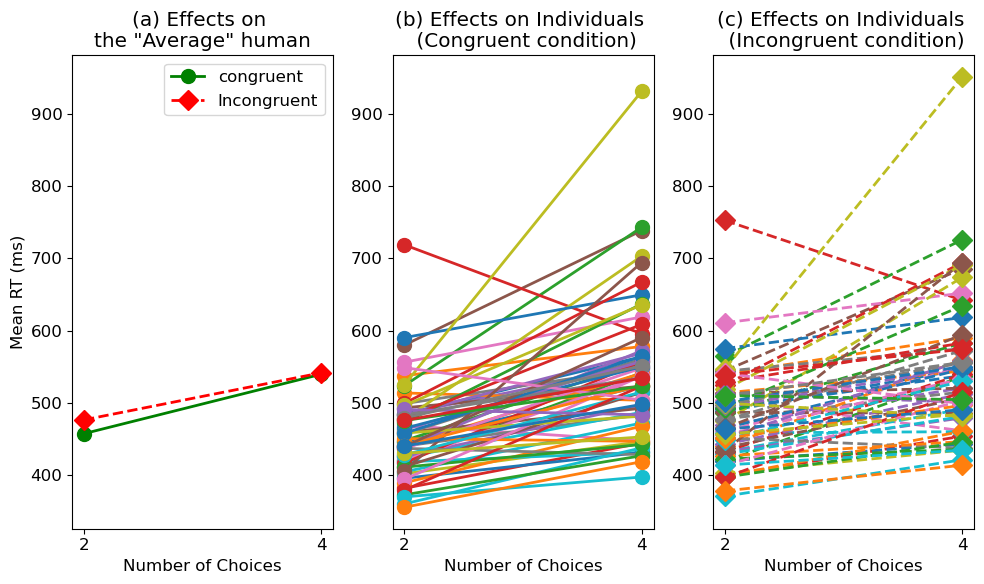

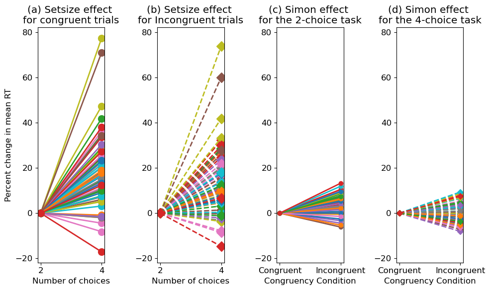

```python
ind_means_n2c1 = [np.mean(agg_data.rt_n2c1.iloc[i]) for i in range(agg_data.shape[0]-1)]
avg_rt_n2c1 = np.mean(ind_means_n2c1)

ind_means_n2c2 = [np.mean(agg_data.rt_n2c2.iloc[i]) for i in range(agg_data.shape[0]-1)]
avg_rt_n2c2 = np.mean(ind_means_n2c2)

ind_means_n4c1 = [np.mean(agg_data.rt_n4c1.iloc[i]) for i in range(agg_data.shape[0]-1)]
avg_rt_n4c1 = np.mean(ind_means_n4c1)

ind_means_n4c2 = [np.mean(agg_data.rt_n4c2.iloc[i]) for i in range(agg_data.shape[0]-1)]
avg_rt_n4c2 = np.mean(ind_means_n4c2)

pc_change_rt_n2c2_wrt_n2c1 = (np.array(ind_means_n2c2) - np.array(ind_means_n2c1))/np.array(ind_means_n2c1)*100
pc_change_rt_n4c1_wrt_n2c1 = (np.array(ind_means_n4c1) - np.array(ind_means_n2c1))/np.array(ind_means_n2c1)*100
pc_change_rt_n4c2_wrt_n2c1 = (np.array(ind_means_n4c2) - np.array(ind_means_n2c1))/np.array(ind_means_n2c1)*100

pc_change_rt_n4c2_wrt_n4c1 = (np.array(ind_means_n4c2) - np.array(ind_means_n4c1))/np.array(ind_means_n4c1)*100
pc_change_rt_n4c2_wrt_n2c2 = (np.array(ind_means_n4c2) - np.array(ind_means_n2c2))/np.array(ind_means_n2c2)*100


## TWO PLOTS

plt.rcParams.update({'font.size': 12})
fig = plt.figure(figsize = (10, 6))
ax1 = fig.add_subplot(131)
ax2 = fig.add_subplot(132, sharey = ax1)
ax3 = fig.add_subplot(133, sharey = ax1)


ax1.plot([2, 4], [avg_rt_n2c1, avg_rt_n4c1], label = "congruent", lw = 2, marker = "o", ms = 10, color = "green")
ax1.plot([2, 4], [avg_rt_n2c2, avg_rt_n4c2], label = "Incongruent", ls = "--", lw = 2, marker = "D", ms = 10, color = "red")
ax1.set_xlabel("Number of Choices")
ax1.set_xticks([2, 4])
ax1.set_ylabel("Mean RT (ms)")
ax1.legend()
ax1.set_title("(a) Effects on \nthe \"Average\" human")

ax2.plot([2, 4], np.c_[ind_means_n2c1, ind_means_n4c1].T, label = "Congruent", lw = 2, marker = "o", ms = 10) #, color = "green")
ax2.set_xlabel("Number of Choices")
ax2.set_xticks([2, 4])
ax2.set_title("(b) Effects on Individuals \n (Congruent condition)")

ax3.plot([2, 4], np.c_[ind_means_n2c2, ind_means_n4c2].T, label = "Incongruent", ls= "--", lw = 2, marker = "D", ms = 10) #, color = "red")
ax3.set_xlabel("Number of Choices")
ax3.set_xticks([2, 4])
ax3.set_title("(c) Effects on Individuals \n (Incongruent condition)")

fig.tight_layout()
plt.savefig("Final_Figs_Ultimate\\Exp2_Figs\\mean_RT_AVG_vs_IND.png", dpi = 300)
plt.show()
plt.close()


## ----------- New plot ------------------

fig = plt.figure(figsize = (10, 6))
ax1 = fig.add_subplot(141)
ax2 = fig.add_subplot(142, sharey = ax1)
ax3 = fig.add_subplot(143, sharey = ax1)
ax4 = fig.add_subplot(144, sharey = ax1)


ax1.plot([2, 4], np.c_[np.zeros_like(pc_change_rt_n4c1_wrt_n2c1), pc_change_rt_n4c1_wrt_n2c1].T, ls= "-", lw = 2, marker = "o", ms = 10)#, color = "blue")
ax1.set_xticks([2, 4])
ax1.set_title("(a) Setsize effect \nfor congruent trials")
ax1.set_xlabel("Number of choices")
ax1.set_ylabel("Percent change in mean RT")
# ax1.grid()

ax2.plot([2, 4], np.c_[np.zeros_like(pc_change_rt_n4c2_wrt_n2c2), pc_change_rt_n4c2_wrt_n2c2].T, ls= "--", lw = 2, marker = "D", ms = 10) #, color = "blue")
ax2.set_xticks([2, 4])
ax2.set_title("(b) Setsize effect \nfor Incongruent trials")
ax2.set_xlabel("Number of choices")
# ax2.set_ylabel("Percent change in mean RT")
# ax2.grid()

ax3.plot([2, 4], np.c_[np.zeros_like(pc_change_rt_n2c2_wrt_n2c1), pc_change_rt_n2c2_wrt_n2c1].T, ls= "-", lw = 2, marker = "o") #, ms = 10, color = "blue")
ax3.set_xticks([2, 4])
ax3.set_xticklabels(["Congruent", "Incongruent"])
ax3.set_title("(c) Simon effect \nfor the 2-choice task")
ax3.set_xlabel("Congruency Condition")
# ax3.set_ylabel("Percent change in mean RT")
# ax3.grid()

ax4.plot([2, 4], np.c_[np.zeros_like(pc_change_rt_n4c2_wrt_n4c1), pc_change_rt_n4c2_wrt_n4c1].T, ls= "--", lw = 2, marker = "D") #, ms = 10, color = "blue")
ax4.set_xticks([2, 4])
ax4.set_xticklabels(["Congruent", "Incongruent"])
ax4.set_title("(d) Simon effect \nfor the 4-choice task")
ax4.set_xlabel("Congruency Condition")
# ax4.set_ylabel("Percent change in mean RT")
fig.tight_layout()
plt.savefig("Final_Figs_Ultimate\\Exp2_Figs\\Percent_change_in_mean_RT_for_all.png", dpi = 300)
plt.show()
plt.close()
# ax1.plot([2, 4], np.c_[np.zeros_like(pc_change_rt_n2c2), pc_change_rt_n2c2].T, label = "Incongruent", ls= "--", lw = 2, marker = "D", color = "red")
# ax2.plot([2, 4], np.c_[np.zeros_like(pc_change_rt_n4c1), pc_change_rt_n4c1].T, label = "Incongruent", ls= "--", lw = 2, marker = "D", color = "red")
# ax3.plot([2, 4], np.c_[np.zeros_like(pc_change_rt_n4c2), pc_change_rt_n4c2].T, label = "Incongruent", ls= "--", lw = 2, marker = "D", color = "red")
```

### Average subject by parameter averaging

We average over all individuals in a condition, specifically for -- the ex-Gaussian distributional parameters the Drift-Diffusion model parameters accuracy

Using the averaged parameters, we then estimate the experimental effect or the changes across conditions of the average subject, as we did for each individual participant.

```python
## --------------------THE AVERAGE SUBJECT ------------------------------------------------
# Let's add the average subject! First we calculate the values, then add them with index 66

# EXG PARAMS, MOMENTS, DDM params and ACC

# n2c1
k_avg_n2c1, mu_avg_n2c1, sigma_avg_n2c1, mean_avg_n2c1, sd_avg_n2c1, skewness_avg_n2c1, kurtosis_avg_n2c1,  \
drift_avg_n2c1, noise_avg_n2c1, bound_avg_n2c1, nondectime_avg_n2c1, mean_acc_n2c1 = \
     [np.mean(agg_data.exg_params_n2c1.apply(lambda x: x[0])), np.mean(agg_data.exg_params_n2c1.apply(lambda x: x[1])), np.mean(agg_data.exg_params_n2c1.apply(lambda x: x[2])),
     np.mean(agg_data.moments_n2c1.apply(lambda x: x[0])), np.mean(agg_data.moments_n2c1.apply(lambda x: x[1])), np.mean(agg_data.moments_n2c1.apply(lambda x: x[2])), np.mean(agg_data.moments_n2c1.apply(lambda x: x[3])),
     np.mean(agg_data.ddm_params_n2c1.apply(lambda x: x[0])), np.mean(agg_data.ddm_params_n2c1.apply(lambda x: x[1])), np.mean(agg_data.ddm_params_n2c1.apply(lambda x: x[2])), np.mean(agg_data.ddm_params_n2c1.apply(lambda x: x[3])),
     np.mean(agg_data.mean_acc_n2c1)]

# n2c2
k_avg_n2c2, mu_avg_n2c2, sigma_avg_n2c2, mean_avg_n2c2, sd_avg_n2c2, skewness_avg_n2c2, kurtosis_avg_n2c2,  \
drift_avg_n2c2, noise_avg_n2c2, bound_avg_n2c2, nondectime_avg_n2c2, mean_acc_n2c2 = \
     [np.mean(agg_data.exg_params_n2c2.apply(lambda x: x[0])), np.mean(agg_data.exg_params_n2c2.apply(lambda x: x[1])), np.mean(agg_data.exg_params_n2c2.apply(lambda x: x[2])),
     np.mean(agg_data.moments_n2c2.apply(lambda x: x[0])), np.mean(agg_data.moments_n2c2.apply(lambda x: x[1])), np.mean(agg_data.moments_n2c2.apply(lambda x: x[2])), np.mean(agg_data.moments_n2c2.apply(lambda x: x[3])),
     np.mean(agg_data.ddm_params_n2c2.apply(lambda x: x[0])), np.mean(agg_data.ddm_params_n2c2.apply(lambda x: x[1])), np.mean(agg_data.ddm_params_n2c2.apply(lambda x: x[2])), np.mean(agg_data.ddm_params_n2c2.apply(lambda x: x[3])),
     np.mean(agg_data.mean_acc_n2c2)]

# n4c1
k_avg_n4c1, mu_avg_n4c1, sigma_avg_n4c1, mean_avg_n4c1, sd_avg_n4c1, skewness_avg_n4c1, kurtosis_avg_n4c1,  \
drift_avg_n4c1, noise_avg_n4c1, bound_avg_n4c1, nondectime_avg_n4c1, mean_acc_n4c1 = \
     [np.mean(agg_data.exg_params_n4c1.apply(lambda x: x[0])), np.mean(agg_data.exg_params_n4c1.apply(lambda x: x[1])), np.mean(agg_data.exg_params_n4c1.apply(lambda x: x[2])),
     np.mean(agg_data.moments_n4c1.apply(lambda x: x[0])), np.mean(agg_data.moments_n4c1.apply(lambda x: x[1])), np.mean(agg_data.moments_n4c1.apply(lambda x: x[2])), np.mean(agg_data.moments_n4c1.apply(lambda x: x[3])),
     np.mean(agg_data.ddm_params_n4c1.apply(lambda x: x[0])), np.mean(agg_data.ddm_params_n4c1.apply(lambda x: x[1])), np.mean(agg_data.ddm_params_n4c1.apply(lambda x: x[2])), np.mean(agg_data.ddm_params_n4c1.apply(lambda x: x[3])),
     np.mean(agg_data.mean_acc_n4c1)]

# n4c2
k_avg_n4c2, mu_avg_n4c2, sigma_avg_n4c2, mean_avg_n4c2, sd_avg_n4c2, skewness_avg_n4c2, kurtosis_avg_n4c2,  \
drift_avg_n4c2, noise_avg_n4c2, bound_avg_n4c2, nondectime_avg_n4c2, mean_acc_n4c2 = \
     [np.mean(agg_data.exg_params_n4c2.apply(lambda x: x[0])), np.mean(agg_data.exg_params_n4c2.apply(lambda x: x[1])), np.mean(agg_data.exg_params_n4c2.apply(lambda x: x[2])),
     np.mean(agg_data.moments_n4c2.apply(lambda x: x[0])), np.mean(agg_data.moments_n4c2.apply(lambda x: x[1])), np.mean(agg_data.moments_n4c2.apply(lambda x: x[2])), np.mean(agg_data.moments_n4c2.apply(lambda x: x[3])),
     np.mean(agg_data.ddm_params_n4c2.apply(lambda x: x[0])), np.mean(agg_data.ddm_params_n4c2.apply(lambda x: x[1])), np.mean(agg_data.ddm_params_n4c2.apply(lambda x: x[2])), np.mean(agg_data.ddm_params_n4c2.apply(lambda x: x[3])),
     np.mean(agg_data.mean_acc_n4c2)]


# Concatenate average subject to the agg_df

num_participant = agg_data.shape[0]
# Create and append an empty row for the avg subject.
empty_row = {col:[""] for col in agg_data.columns}
x = pd.DataFrame(empty_row, index = [66])
agg_data = pd.concat([agg_data, x])

agg_data.at[num_participant + 1, "exg_params_n2c1"] = (k_avg_n2c1, mu_avg_n2c1, sigma_avg_n2c1)
agg_data.at[num_participant + 1, "exg_params_n4c1"] = (k_avg_n4c1, mu_avg_n4c1, sigma_avg_n4c1)
agg_data.at[num_participant + 1, "exg_params_n2c2"] = (k_avg_n2c2, mu_avg_n2c2, sigma_avg_n2c2)
agg_data.at[num_participant + 1, "exg_params_n4c2"] = (k_avg_n4c2, mu_avg_n4c2, sigma_avg_n4c2)

agg_data.at[num_participant + 1, "moments_n2c1"] = (mean_avg_n2c1, sd_avg_n2c1, skewness_avg_n2c1, kurtosis_avg_n2c1)
agg_data.at[num_participant + 1, "moments_n4c1"] = (mean_avg_n4c1, sd_avg_n4c1, skewness_avg_n4c1, kurtosis_avg_n4c1)
agg_data.at[num_participant + 1, "moments_n2c2"] = (mean_avg_n2c2, sd_avg_n2c2, skewness_avg_n2c2, kurtosis_avg_n2c2)
agg_data.at[num_participant + 1, "moments_n4c2"] = (mean_avg_n4c2, sd_avg_n4c2, skewness_avg_n4c2, kurtosis_avg_n4c2)

agg_data.loc[num_participant + 1, "mean_acc_n2c1"] = mean_acc_n2c1
agg_data.loc[num_participant + 1, "mean_acc_n4c1"] = mean_acc_n4c1
agg_data.loc[num_participant + 1, "mean_acc_n2c2"] = mean_acc_n2c2
agg_data.loc[num_participant + 1, "mean_acc_n4c2"] = mean_acc_n4c2

agg_data.at[num_participant + 1, "ddm_params_n2c1"] = (drift_avg_n2c1, noise_avg_n2c1, bound_avg_n2c1, nondectime_avg_n2c1)
agg_data.at[num_participant + 1, "ddm_params_n4c1"] = (drift_avg_n4c1, noise_avg_n4c1, bound_avg_n4c1, nondectime_avg_n4c1)
agg_data.at[num_participant + 1, "ddm_params_n2c2"] = (drift_avg_n2c2, noise_avg_n2c2, bound_avg_n2c2, nondectime_avg_n2c2)
agg_data.at[num_participant + 1, "ddm_params_n4c2"] = (drift_avg_n4c2, noise_avg_n4c2, bound_avg_n4c2, nondectime_avg_n4c2)

# Calculate REs

dist_params =  agg_data.loc[num_participant + 1, ['exg_params_n2c1', 'exg_params_n2c2', 'exg_params_n4c1', 'exg_params_n4c2']]
# for an all by re matrix
re_matrix = np.zeros([4, 4])

for i_x in range(4): # p(x) index
     for i_ref in range(4): # pref index
          re_matrix[i_x, i_ref] = RE_uni_exg_numerical(params_px = dist_params[i_x], params_pref = dist_params[i_ref])
agg_data.at[num_participant + 1, "RE_all"] = re_matrix

agg_data.at[num_participant + 1, "avg_setsize_effect"] = (re_matrix[2,0] + re_matrix[3,1] + re_matrix[0,2] + re_matrix[1,3])/4
# We estimate setsize by the relative entropy between distributions across congruency conditions, for each set size.
agg_data.at[num_participant + 1, "avg_simon_effect"] = (re_matrix[1,0] + re_matrix[0,1] + re_matrix[2,3] + re_matrix[3,2])/4

# Set size effect to Simon effect ratio (need a better, self-explanatory name)
# higher means relatively more affected by setsize than stimulus response incompatibility.
agg_data.at[num_participant + 1, "effect_ratio"] = agg_data.at[num_participant + 1, "avg_setsize_effect"]/agg_data.at[num_participant + 1, "avg_simon_effect"]
# agg_data.re_all[num_participant + 1] = np.random.random(size = [4,4])
```

## Simon vs Setsize

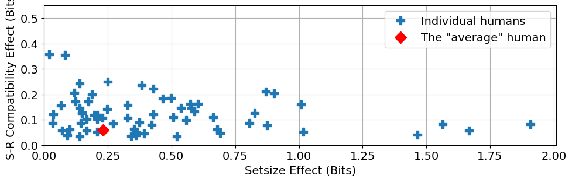

```python
plt.rcParams.update({'font.size': 14})
fig = plt.figure(figsize = (10, 4))
ax = fig.add_subplot(111, aspect = "equal")
ax.plot(agg_data.avg_setsize_effect, agg_data.avg_simon_effect, ls = "", marker = "P", markersize = 10, label = "Individual humans")
ax.set_xlim([0, 2.01])
ax.set_ylim([0, 0.55])
ax.grid()
ax.set_xlabel("Setsize Effect (Bits)")
ax.set_ylabel("S-R Compatibility Effect (Bits)")


ax.plot(agg_data.avg_setsize_effect.iloc[-1], agg_data.avg_simon_effect.iloc[-1], ls = "", marker = "D", markersize = 10, color = "red", label = "The \"average\" human")
ax.legend()

# plt.show()
fig.tight_layout()
plt.savefig("Final_Figs_Ultimate\\Exp2_Figs\\Average_Effect_all_and_NO_clustering.png", dpi = 300)
plt.show()
plt.close()
```

```python
# x = agg_data.avg_setsize_effect
# y = agg_data.avg_simon_effect


# # def scatter_hist(x, y, ax, ax_histx, ax_histy):
# #     # no labels


# # Start with a square Figure.
# fig = plt.figure(figsize=(16, 10))
# # Add a gridspec with two rows and two columns and a ratio of 1 to 4 between
# # the size of the marginal Axes and the main Axes in both directions.
# # Also adjust the subplot parameters for a square plot.
# gs = fig.add_gridspec(2, 2,  width_ratios=(4, 1), height_ratios=(1, 4),
#                       left=0.1, right=0.9, bottom=0.1, top=0.9,
#                       wspace=0.05, hspace=0.05)
# # Create the Axes.
# ax = fig.add_subplot(gs[1, 0])
# ax_histx = fig.add_subplot(gs[0, 0], sharex=ax)
# ax_histy = fig.add_subplot(gs[1, 1], sharey=ax)
# # Draw the scatter plot and marginals.
# # scatter_hist(x, y, ax, ax_histx, ax_histy)

# ax_histx.tick_params(axis="x", labelbottom=False)
# ax_histy.tick_params(axis="y", labelleft=False)

# # the scatter plot:
# ax.plot(x, y, ls = "", marker = "P", markersize = 10, label = "Individual humans")
# ax.set_xlim([0, 2.01])
# ax.set_ylim([0, 0.51])
# ax.grid()
# ax.set_xlabel("Setsize Effect (Bits)")
# ax.set_ylabel("S-R Compatibility Effect (Bits)")


# # ax.plot(agg_data.avg_setsize_effect.iloc[-1], agg_data.avg_simon_effect.iloc[-1], ls = "", marker = "D", markersize = 10, color = "red", label = "The \"average\" human")
# # ax.legend()

# # plt.show()
# # now determine nice limits by hand:
# # binwidth = 0.25
# # xymax = max(np.max(np.abs(x)), np.max(np.abs(y)))
# # lim = (int(xymax/binwidth) + 1) * binwidth

# bins = np.arange(-lim, lim + binwidth, binwidth)
# sns.distplot(x, ax = ax_histx, color = "red")
# sns.kdeplot(y, ax = ax_histy, color = "red", vertical = True)

# # now determine nice limits by hand:
# binwidth = 0.01
# xymax = max(np.max(np.abs(x)), np.max(np.abs(y)))
# lim = (int(xymax/binwidth) + 1) * binwidth

# bins = np.arange(-lim, lim + binwidth, binwidth)
# # ax_histx.hist(x, bins=bins)
# ax_histy.hist(y, bins=bins, orientation='horizontal')
```

## Finding sub-groups of individuals based on distributional changes as effect sizes

Effect size measured by: (1) Relative Entropy. (2) Percent changes of $\mu$ and $\tau$ of Ex-Gaussian Distributions, individually and together. (3) Percent changes of DDM parameters (4) Overlapping index

(5) Individual differences of our reference condition: i.e., in congruent trials of 2-choice task condition.

```
Then clustering people based on similarity of distributions directly. Interesting questions:
(1) How does the partitions of people in this case compare to the partitions based on effect sizes?
In other words, do the people who are similar in our reference condition, show similar effects?

(2) Individual differences vs the experimental effects!
Changes of whole distributions (i.e., using RE and OI)
```

Finally, AMI/ARI among the partitions to quantify how similar or different they are.

Appendix:

1. Relative entropy maps for all, ranked by effect ratio
2. Detailed results for each individual
3. Different measures for effect size and partitions of people into sub-groups
4. (a) Experimental effects for experiments 1, 2, and 4 (b) SRC effect on Simon tasks (or Simon Effect) on people with Parkinson's vs Healthy controls (c) SRC effect on Stroop tasks (or Stroop Effect) [Not needed this time I think]

```python
## Declare the spectral cluster model
    ## We are implementing to get THREE groups.
    ## We could choose other values. But we already got great modularity values.

spectral_model_1_nearest_neighbors = cluster.SpectralClustering(
        n_clusters=3,
        eigen_solver="arpack",
        affinity="nearest_neighbors",
        random_state=2,
    )

spectral_model_2_based_on_precomputed_affinity = cluster.SpectralClustering(
        n_clusters=3,
        eigen_solver="arpack",
        affinity="precomputed",
        random_state=2,
    )
```

### Case 1: Average Simon effect and Setsize Effect

```
modularity =  0.563
```

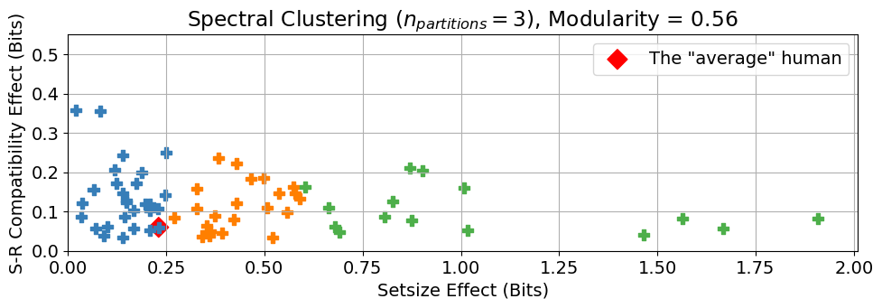

```python
x_for_effect1_case1 = np.array(agg_data.avg_setsize_effect)
y_for_effect2_case1 = np.array(agg_data.avg_simon_effect)

all_effects_matrix_case1 = np.c_[x_for_effect1_case1, y_for_effect2_case1]

spectral_model_1_nearest_neighbors.fit(all_effects_matrix_case1)
class_pred_case1 = spectral_model_1_nearest_neighbors.labels_.astype(int)
colors = np.array(
    list(
        itertools.islice(
            itertools.cycle(
                [
                    "#377eb8",
                    "#ff7f00",
                    "#4daf4a",
                    "#f781bf",
                    "#a65628",
                    "#984ea3",
                    "#999999",
                    "#e41a1c",
                    "#dede00",
                ]
            ),
            int(max(class_pred_case1) + 1),
        )
    )
)
colors = np.append(colors, ["#000000"])


# Convert class labels to groups or communities
communities_spectral_clustering_case1 = [list(np.concatenate(np.argwhere(class_pred_case1 == class_label))) for class_label in range(max(class_pred_case1)+1)]

# Get the affinity matrix from Spectral Clustering --> Adj matrix
affinity_matrix_nearest_neighbor = spectral_model_1_nearest_neighbors.affinity_matrix_.toarray()
adj_matrix_x_case1 = copy.copy(affinity_matrix_nearest_neighbor) # Create Adjacency Matrix
for i in range(adj_matrix_x_case1.shape[0]): # Need to make the diagonal elements zero.
    adj_matrix_x_case1[i, i] = 0

# Create network
G_x_case1 = nx.from_numpy_array(adj_matrix_x_case1)

modularity_of_spectral_clustering_case1 = round(nx.community.modularity(G_x_case1, communities_spectral_clustering_case1), len(communities_spectral_clustering_case1))

print("modularity = ", modularity_of_spectral_clustering_case1)


## ------------- Plotting ---------------


fig = plt.figure(figsize = (10, 4))
ax1 = fig.add_subplot(111, aspect = "equal")
# ax2 = fig.add_subplot(212)
ax1.scatter(x_for_effect1_case1[-1], y_for_effect2_case1[-1], ls = "", marker = "D", s = 125, color = "red", label = "The \"average\" human")
ax1.scatter(x_for_effect1_case1, y_for_effect2_case1, ls = "", marker = "P", s = 75, color = colors[class_pred_case1])
ax1.legend()
ax1.set_xlim([0, 2.01])
ax1.set_ylim([0, 0.55])
ax1.grid()
ax1.set_xlabel("Setsize Effect (Bits)")
ax1.set_ylabel("S-R Compatibility Effect (Bits)")
ax1.set_title(r"Spectral Clustering ($n_{partitions} = 3$), Modularity = %1.2f"%modularity_of_spectral_clustering_case1)
fig.tight_layout()

# visualize_communities_RR(G_x1, communities_spectral_clustering, ax = ax2, node_colors_by_community = list(colors[class_pred]), algorithm="", seed_to_set= 10)

plt.savefig("Final_Figs_Ultimate\\Exp2_Figs\\Average_Effect_all_and_spectral_clusters_of_self.png", dpi = 300)
plt.show()
plt.close()
```

### Case 2: Experimental effect through RE between all pairs of conditions

Instead of using the average effects, we can use pairwise comparisons of distributions. Six unique pairs of conditions --> the experimental effect on each individual as a point vector of six relative entropy values. In this case, the partitions are determined based on the eigenvalues and eigenvectors in the six-dimensional space, compared to the 2D effect space used earlier.

```python
def create_flat_RE_array_from_matrix(given_matrix):
    flattened_array = np.array([])
    for row_i in range(1, len(given_matrix)):
        temp = given_matrix[row_i, :row_i]
        # print(temp)
        flattened_array = np.concatenate([flattened_array, temp])
    return(flattened_array)
# create_flat_RE_array_from_matrix(agg_data.RE_all.iloc[2])
```

```
modularity =  0.438
```

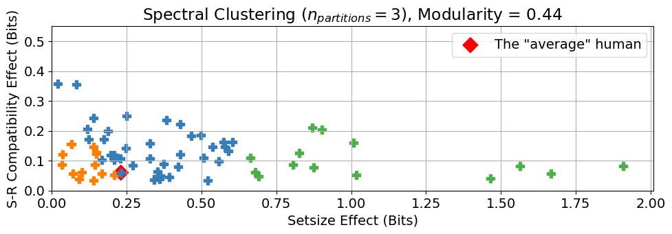

```python
all_effects_matrix_case2 = np.vstack(agg_data.RE_all.apply(lambda x: (x+x.T)/2).apply(create_flat_RE_array_from_matrix).values)


spectral_model_1_nearest_neighbors.fit(all_effects_matrix_case2)
class_pred_case2 = spectral_model_1_nearest_neighbors.labels_.astype(int)
colors = np.array(
    list(
        itertools.islice(
            itertools.cycle(
                [
                    "#377eb8",
                    "#ff7f00",
                    "#4daf4a",
                    "#f781bf",
                    "#a65628",
                    "#984ea3",
                    "#999999",
                    "#e41a1c",
                    "#dede00",
                ]
            ),
            int(max(class_pred_case2) + 1),
        )
    )
)
colors = np.append(colors, ["#000000"])


# Convert class labels to groups or communities
communities_spectral_clustering_case2 = [list(np.concatenate(np.argwhere(class_pred_case2 == class_label))) for class_label in range(max(class_pred_case2)+1)]

# Get the affinity matrix from Spectral Clustering --> Adj matrix
affinity_matrix_nearest_neighbor = spectral_model_1_nearest_neighbors.affinity_matrix_.toarray()
adj_matrix_x_case2 = copy.copy(affinity_matrix_nearest_neighbor) # Create Adjacency Matrix
for i in range(adj_matrix_x_case2.shape[0]): # Need to make the diagonal elements zero.
    adj_matrix_x_case2[i, i] = 0

# Create network
G_x_case2 = nx.from_numpy_array(adj_matrix_x_case2)

modularity_of_spectral_clustering_case2 = round(nx.community.modularity(G_x_case2, communities_spectral_clustering_case2), len(communities_spectral_clustering_case2))

print("modularity = ", modularity_of_spectral_clustering_case2)


## ------------- Plotting ---------------


fig = plt.figure(figsize = (10, 4))
ax1 = fig.add_subplot(111, aspect = "equal")
# ax2 = fig.add_subplot(212)

# We keep the plot constant from case1
ax1.scatter(x_for_effect1_case1[-1], y_for_effect2_case1[-1], ls = "", marker = "D", s = 125, color = "red", label = "The \"average\" human")
ax1.scatter(x_for_effect1_case1, y_for_effect2_case1, ls = "", marker = "P", s = 75, color = colors[class_pred_case2])
ax1.legend()
ax1.set_xlim([0, 2.01])
ax1.set_ylim([0, 0.55])
ax1.grid()
ax1.set_xlabel("Setsize Effect (Bits)")
ax1.set_ylabel("S-R Compatibility Effect (Bits)")
ax1.set_title(r"Spectral Clustering ($n_{partitions} = 3$), Modularity = %1.2f"%modularity_of_spectral_clustering_case2)
fig.tight_layout()

# visualize_communities_RR(G_x1, communities_spectral_clustering, ax = ax2, node_colors_by_community = list(colors[class_pred]), algorithm="", seed_to_set= 10)

plt.savefig("Final_Figs_Ultimate\\Exp2_Figs\\Average_Effect_all_and_spectral_clusters_of_6_RE.png", dpi = 300)
plt.show()
plt.close()
```